# CN Status Heatmap

Candace Savonen for ALSF - CCDL

2020

## Purpose:

Create a summary heatmap of copy number status from the consensus CNV call data. This is done by binning the genome and calculating the segment’s coverage of the CNV consensus segments. A bin is declared a particular copy number status if that status’s base pair coverage fraction is above a certain threshold (`frac_threshold`) and the callable portion of the bin is higher than the threshold, `frac_uncallable`.

### Usage

This notebook can be run via the command line from the top directory of the repository as follows:

```
Rscript -e "rmarkdown::render('analyses/cnv-chrom-plot/cn_status_heatmap.Rmd',
                              clean = TRUE)"
```

### Cutoffs:

```r
# The max length of a segment to use the data.
# segments that are too long may dominate the heatmap and/or be indicators of
# broader structural changes
length_max <- 1e7

# Set minimum percentage of a bin that should be callable to report data.
frac_uncallable <- 0.75

# Absolute fraction needed for a bin to be called a particular status
frac_threshold <- 0.75

# Any groups smaller than this will be added into the `Other` group for the resulting heatmap
min_group_size <- 2
```

### Set Up

```r
# Magrittr pipe
`%>%` <- dplyr::`%>%`
```

### Directories and Files

```r
# Path to input directory
input_dir <- file.path("..", "..", "data")
figure_dir <- file.path("..", "..", "figures")
scratch_dir <- file.path("..", "..", "scratch")
cnv_dir <- file.path("..", "copy_number_consensus_call", "results")

# Path to output directory based on whether this is called by the generate-figures.sh script or not
plots_dir <- ifelse(params$final_figure, file.path(figure_dir, "pngs"),  "plots")
results_dir <- "results"

# Create the plots_dir if it does not exist
if (!dir.exists(plots_dir)) {
  dir.create(plots_dir, recursive = TRUE)
}

# Create the results_dir if it does not exist
if (!dir.exists(results_dir)) {
  dir.create(results_dir, recursive = TRUE)
}
```

Read in custom functions.

```r
source(file.path("util", "bin-coverage.R"))
```

Import color palettes.

```r
# Import standard color palettes for project
histology_label_mapping <- readr::read_tsv(
  file.path(figure_dir, "palettes", "histology_label_color_table.tsv")
  ) %>%
  # Select just the columns we will need for plotting
  dplyr::select(Kids_First_Biospecimen_ID, display_group, display_order, hex_codes)
```

Read in the divergent color palette and set it up with three colors. In this instance, we only need three values for `gain`, `neutral`, and `loss`.

```r
divergent_col_palette <- readr::read_tsv(
  file.path(figure_dir, "palettes", "divergent_color_palette.tsv")
) %>%
  # Only keep only these three colors
  dplyr::filter(
    color_names %in% c("divergent_low_4", "divergent_neutral", "divergent_high_4")
  ) %>%
  dplyr::pull("hex_codes")
```

### Read in data

```r
# Read in metadata
metadata <-
  readr::read_tsv(file.path(input_dir, "pbta-histologies.tsv"), guess_max = 10000) %>%
  # Join on the colors
  dplyr::left_join(histology_label_mapping, by = "Kids_First_Biospecimen_ID")
```

### Set up consensus copy number data

```r
# Read in the segment copy number data
seg_data <- data.table::fread(
  file.path(
    cnv_dir,
    "pbta-cnv-consensus.seg.gz"
  ),
  data.table = FALSE
)
```

Set up the status for each consensus segment.

```r
seg_data <- seg_data %>%
  # Join the histology column to this data
  dplyr::inner_join(
    dplyr::select(
      metadata,
      "Kids_First_Biospecimen_ID",
      "display_group",
      "tumor_ploidy"
    ),
    by = c("ID" = "Kids_First_Biospecimen_ID")
  ) %>%
  # Reformat the chromosome variable to drop the "chr"
  dplyr::mutate(chrom = factor(gsub("chr", "", chrom),
    levels = c(1:22, "X", "Y")
  )) %>%
  # Recode the copy number status based on ploidy
  dplyr::mutate(status = dplyr::case_when(
    # when the copy number is less than inferred ploidy, mark this as a loss
    copy.num < tumor_ploidy ~ "loss",
    # if copy number is higher than ploidy, mark as a gain
    copy.num > tumor_ploidy ~ "gain",
    copy.num == tumor_ploidy ~ "neutral"
  )) %>%
  # Remove sex chromosomes
  dplyr::filter(
    !(chrom %in% c("X", "Y", "M")),
    !is.na(status)
  )
```

Set up seg data as GenomicRanges.

```r
seg_ranges <- GenomicRanges::GRanges(
  seqnames = seg_data$chrom,
  ranges = IRanges::IRanges(
    start = seg_data$loc.start,
    end = seg_data$loc.end
  ),
  status = seg_data$status,
  histology = seg_data$display_group,
  biospecimen = seg_data$ID
)
```

Explore the distribution of segment lengths.

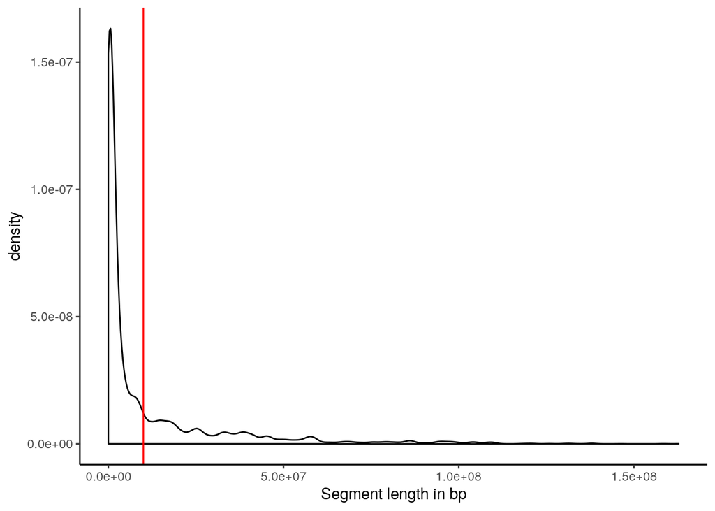

```r
ggplot2::qplot(seg_ranges@ranges@width, geom = "density") +
  ggplot2::theme_classic() +
  ggplot2::ylab("density") +
  ggplot2::xlab("Segment length in bp") +
  # Let's put a vertical line where we will make a filter cutoff
  ggplot2::geom_vline(xintercept = length_max, color = "red")
```

Filter out segments that are longer than our cutoff.

```r
filtered_seg_ranges <- seg_ranges[which(seg_ranges@ranges@width < length_max)]
```

### Set up chromosomal sizes for making bins.

(This has nothing to do with Strelka, but it just so happens this is a file with the sizes of the chromosomes in this genome build, hg38).

```r
chr_sizes <- readr::read_tsv(file.path(input_dir, "WGS.hg38.strelka2.unpadded.bed"),
  col_names = c("chrom", "start", "end")
) %>%
  # Reformat the chromosome variable to drop the "chr"
  dplyr::mutate(chrom = factor(gsub("chr", "", chrom),
    levels = c(1:22, "X", "Y", "M")
  )) %>%
  # Remove sex chromosomes
  dplyr::filter(!(chrom %in% c("X", "Y", "M")))
# Make chromosome size named vector for Heatmap annotation
chr_sizes_vector <- chr_sizes$end
names(chr_sizes_vector) <- chr_sizes$chrom
```

### Set up uncallable regions data

```r
uncallable_bed <- readr::read_tsv(
  file.path(
    "..",
    "copy_number_consensus_call",
    "ref",
    "cnv_excluded_regions.bed"
  ),
  col_names = c("chrom", "start", "end")
) %>%
  # Reformat the chromosome variable to drop the "chr"
  dplyr::mutate(chrom = factor(gsub("chr", "", chrom),
    levels = c(1:22, "X", "Y")
  )) %>%
  dplyr::filter(
    # Drop CNVs that don't have chromosome labels
    !is.na(chrom),
    # Drop sex chromosomes
    !(chrom %in% c("X", "Y", "M"))
  )
```

Set up uncallable regions as GenomicRanges.

```r
uncallable_ranges <- GenomicRanges::GRanges(
  seqnames = uncallable_bed$chrom,
  ranges = IRanges::IRanges(
    start = uncallable_bed$start,
    end = uncallable_bed$end
  )
)
```

Set up binned genome ranges.

```r
# Set up bins of ~1Mb size
bins <- GenomicRanges::tileGenome(
  chr_sizes_vector,
  tilewidth = 1e6
)
# Uncompress these ranges
bins <- unlist(bins)
```

## Set up heatmap annotation objects

Make color key.

```r
color_key <- structure(c(divergent_col_palette, "#9932CC", "#fed8b1"),
  names = c("loss", "neutral", "gain", "unstable", "uncallable")
)
```

### Make column annotation object

Extract chromosome labels and make an alternating color key for them. This annotation object strategy was originally from [chromosomal-instability](https://github.com/AlexsLemonade/OpenPBTA-analysis/blob/b5a33838d1e9bd7e7913a89201ec26125c16c94c/analyses/chromosomal-instability/02a-plot-chr-instability-heatmaps.Rmd#L73).

```r
# Set up chromosome labels from bins as a factor vector
chrs <- paste0("chr", S4Vectors::decode(bins@seqnames))
chrs <- factor(chrs, levels = paste0("chr", 1:22))

# Make a key for assigning alternating colors to the chromosomes
chr_colors <- rep(c("white", "black"),
  length.out = length(unique(chrs))
)
names(chr_colors) <- unique(chrs)

# Get coordinate start positions
chr_start <- match(unique(chrs), chrs)

# Get coordinate end positions
chr_end <- chr_start + summary(chrs)

# Get mid points of chromosome labels
mid_points <- floor((chr_start + chr_end) / 2)
```

Make chromosomal labeling `HeatmapAnnotation` object.

```r
# Make text labels for chromosome text
chr_text <- ComplexHeatmap::anno_mark(
  at = mid_points,
  labels = levels(chrs),
  which = "column",
  side = "bottom",
  labels_rot = 45,
  labels_gp = grid::gpar(cex = 0.65)
)

# Create the Heatmap annotation object
chr_annot <- ComplexHeatmap::HeatmapAnnotation(
  df = data.frame(chrs),
  col = list(chrs = chr_colors),
  name = "",
  show_legend = FALSE,
  show_annotation_name = FALSE,
  mark = chr_text, # Put the text in
  border = TRUE
)
```

### Make row annotation object

Make histology labeling `HeatmapAnnotation` object. This annotation object strategy was originally from [chromosomal-instability](https://github.com/AlexsLemonade/OpenPBTA-analysis/blob/b5a33838d1e9bd7e7913a89201ec26125c16c94c/analyses/chromosomal-instability/02a-plot-chr-instability-heatmaps.Rmd#L73).

```r
# Get the histologies for the samples in this set and order them by histology
histologies <-
  data.frame(Kids_First_Biospecimen_ID = bin_calls_df$biospecimen_id) %>%
  dplyr::inner_join(metadata %>%
    dplyr::select(Kids_First_Biospecimen_ID, display_group, display_order, hex_codes)) %>%
  # Count numbers of samples per histology group and make new variable with counts
  dplyr::group_by(display_group) %>%
  dplyr::mutate(group_n = dplyr::n()) %>%
  # Ungroup the data
  dplyr::ungroup() %>%
  # Add sample sizes
  dplyr::mutate(display_group = factor(paste0(display_group, " (n = ", group_n, ")"))) %>%
  # Reorder display_group based on display_order
  dplyr::mutate(display_group = forcats::fct_reorder(display_group, display_order)) %>%
  # Make sure they are in display_order
  dplyr::arrange(display_order) %>%
  # Store as rownames
  tibble::column_to_rownames("Kids_First_Biospecimen_ID") %>%
  # We don't want this to actually be displayed on the heatmap though
  dplyr::select(-display_order)
```

Make a color key that’s formatted for ComplexHeatmap.

```r
# Get a distinct version of the color keys
histologies_color_key_df <- histologies %>%
  dplyr::select(display_group, hex_codes) %>%
  dplyr::distinct()

# Make color key specific to these samples
histologies_color_key <- histologies_color_key_df$hex_codes
names(histologies_color_key) <- histologies_color_key_df$display_group

# Get coordinate start positions
hist_start <- match(names(histologies_color_key), histologies$display_group)

# Get coordinate end positions for each histology group
hist_end <- hist_start + summary(histologies$display_group)

# Get mid points of
mid_points <- floor((hist_start + hist_end) /2)
```

```r
# Make text labels for chromosome text
hist_text <- ComplexHeatmap::anno_mark(
  at = mid_points,
  labels = levels(histologies$display_group),
  which = "row",
  side = "right",
  labels_gp = grid::gpar(cex = 0.65),
  link_width = grid::unit(15, "mm")
)

# Create the Heatmap annotation object
hist_annot <- ComplexHeatmap::HeatmapAnnotation(
  df = data.frame(histologies) %>% dplyr::select(-group_n, -hex_codes),
  col = list(display_group = histologies_color_key),
  which = "row",
  show_annotation_name = FALSE,
  show_legend = FALSE,
  mark = hist_text, # Put the text in
  border = TRUE
  )
```

Format `bin_calls_df` as a matrix with rownames for `ComplexHeatmap` to use.

```r
bin_calls_mat <- bin_calls_df %>%
  tibble::column_to_rownames("biospecimen_id") %>%
  as.matrix()

# Ensure that this matrix is in the same order as the annotation
bin_calls_mat <- bin_calls_mat[rownames(histologies), ]

# Double check its in thte same order
all.equal(rownames(bin_calls_mat), rownames(histologies))
```

```
[1] TRUE
```

## Assemble CN status heatmap

```r
# Plot on a heatmap
heatmap <- ComplexHeatmap::Heatmap(
  bin_calls_mat,
  name = "CN status",
  col = color_key,
  row_split = histologies$display_group,
  cluster_columns = FALSE,
  cluster_rows = FALSE,
  rect_gp = grid::gpar(col = "black", lwd = .0005),
  show_column_names = FALSE,
  show_row_names = FALSE,
  row_labels = FALSE,
  bottom_annotation = chr_annot,
  right_annotation = hist_annot,
  heatmap_legend_param = list(nrow = 1, border = "black"),
  raster_quality = 8,
  border = "black",
  row_title = NULL
)
```

Print out heatmap.

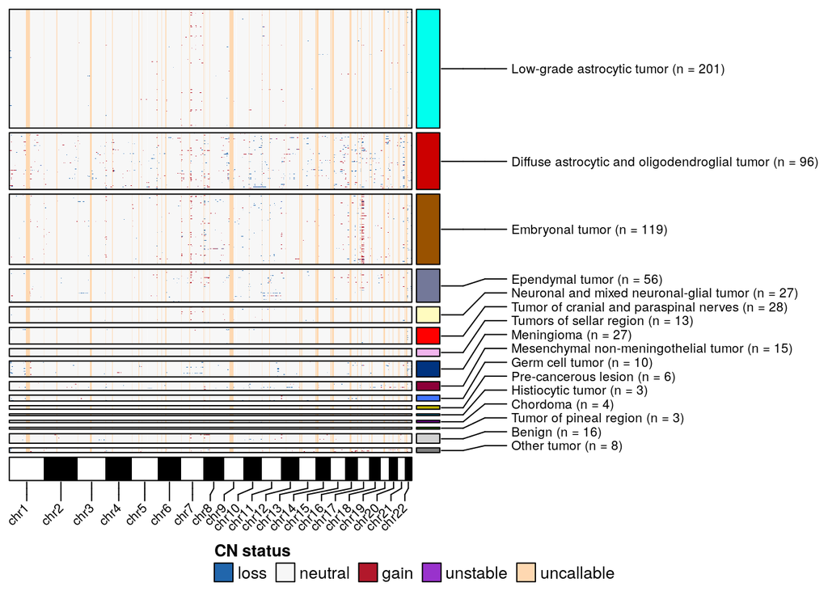

```r
ComplexHeatmap::draw(heatmap, heatmap_legend_side = "bottom")
```

Save to PNG.

```r
# Save plot as PNG
png(file.path(plots_dir, "cn_status_heatmap.png"),
    res = 800, width = 8.5, height = 11.5, units = "in")
ComplexHeatmap::draw(heatmap, heatmap_legend_side = "bottom")
dev.off()
```